# iPSC clustering: are there hidden cell cycle effects?

Kushal K Dey, Joyce H. Siao

July 21, 2015

When we performed Structure on the single cell - gene data table of counts, with the aim to cluster the single cells, we observed that the individual effets largely drove the clusters and the cell cycle specific effects did not show up. A general feeling is that if we account for the individual effect as a batch effect and redo our analysis, we should get the cell cycle information getting reflected in the cluster patterns. But is it true?…What if we do the analysis and then find that the cell cycle specific effects do not show up?…Can we be little more confident about what whether we would get some cell cycle driven clusters once we use individual information as a batch effect in our statistical model. One way to figure this out would be to cluster the single cells by the Structure model

We first choose the single cells coming from the first individual.

```
##
## Estimating on a 157 document collection.
## Fitting the 5 topic model.
## log posterior increase: 6556.868, 4293.531, 1431.139, 1113.775, 794.204, 538.607, 361.327, 257.177, 189.324, 143.869, 113.44, 92.059, 76.968, 65.106, 55.644, 48.018, 42.007, 37.149, 33.097, 29.692, 26.964, done.
```

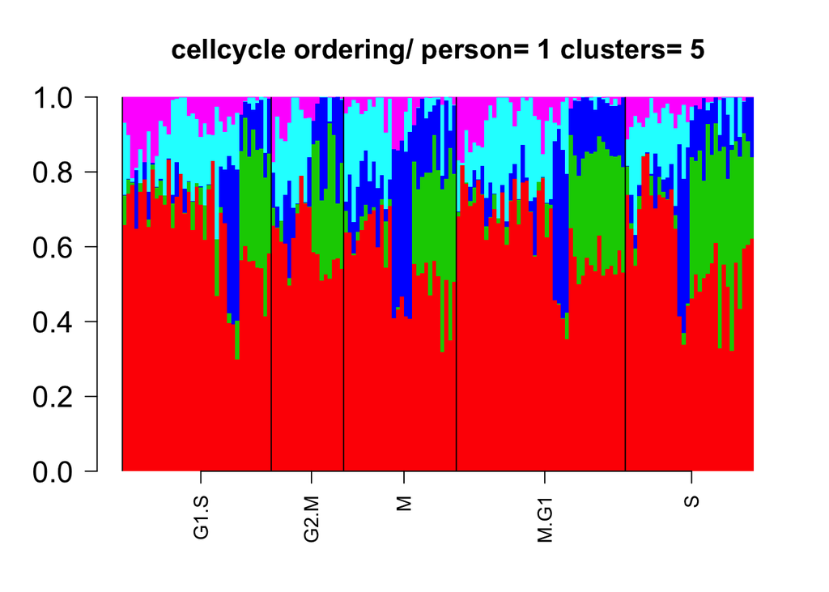

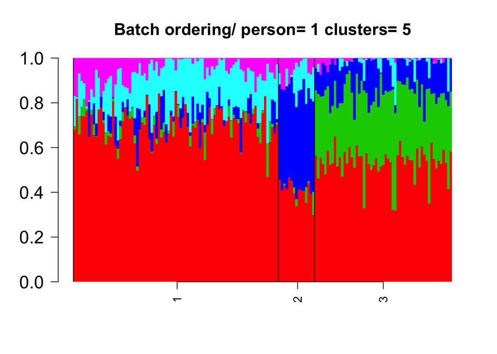

```r
#cell_phase <- apply(ans_normed_normed,1,function(x) colnames(cell_cycle_genes)[which.max(x)])

structure_per_individual <- function(counts_data,individual_lab,nclus,cell_phase)
{
  subgroup_id =colnames(counts_data);
  individual_effect = unlist(lapply(strsplit(subgroup_id, "\\."), function(x) x[1]));
  batch = unlist(lapply(strsplit(subgroup_id, "\\."), function(x) x[2]));

 # indices <- which(individual_effect==unique(individual_effect)[individual_lab] &
  #                   batch_effect==unique(batch_effect)[batch_lab] );

  indices <- which(individual_effect==unique(individual_effect)[individual_lab]);

  counts_ind <- counts_data[,indices];

  Topic_Clus <- topics(t(counts_ind), K=nclus, tol=0.005);

  cell_phase_ind <- cell_phase[indices];

  docweights_ind <- Topic_Clus$omega;

  cell_phase_ind_ordered <- cell_phase_ind[order(cell_phase_ind)];

  docweights_ind_ordered <- docweights_ind[order(cell_phase_ind),];

  barplot(t(docweights_ind_ordered),col=2:(nclus+1),axisnames=F,space=0,border=NA,main=paste("cellcycle ordering/ person=",individual_lab,"clusters=",nclus),las=1,ylim=c(0,1),cex.axis=1.5,cex.main=1.4)

  labels = match(unique(cell_phase_ind_ordered), cell_phase_ind_ordered);
  abline(v=labels-1)

  labels_low=labels;
  labels_up=c(labels[2:length(labels)],dim(docweights_ind_ordered)[1]);
  mid_point=labels_low +0.5*(labels_up-labels_low);

  axis(1,at=mid_point, unique(cell_phase_ind_ordered),las=2);

  batch_ind <- batch[indices];
  batch_ind_ordered <- batch_ind[order(batch_ind)];

  docweights_ind_ordered = docweights_ind[order(batch_ind),];

barplot(t(docweights_ind_ordered),col=2:(nclus+1),axisnames=F,space=0,border=NA,main=paste("Batch ordering/ person=",individual_lab,"clusters=",nclus),las=1,ylim=c(0,1),cex.axis=1.5,cex.main=1.4)

labels = match(unique(batch_ind_ordered), batch_ind_ordered);
abline(v=labels-1)

labels_low=labels-1;
labels_up=c(labels[2:length(labels)],dim(docweights_ind_ordered)[1]);
mid_point=labels_low +0.5*(labels_up-labels_low);

axis(1,at=mid_point, unique(batch_ind_ordered),las=2);



}


structure_per_individual(molecules_single,1,nclus=5,cell_phase)
```

```r
structure_per_individual(molecules_single,2,nclus=5,cell_phase)
```

```
##
## Estimating on a 197 document collection.
## Fitting the 5 topic model.
## log posterior increase: 7156.153, 4224.378, 1677.843, 1244.178, 854.119, 583.805, 414.901, 311.651, 252.505, 214.442, 185.658, 163.017, 148.114, 131.944, 114.896, 101.796, 88.31, 74.727, 65.189, 58.037, done.
```

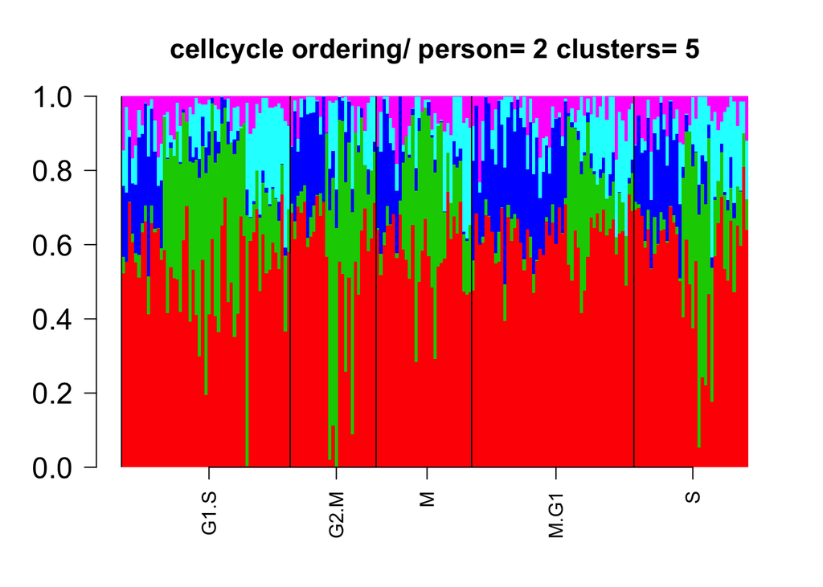

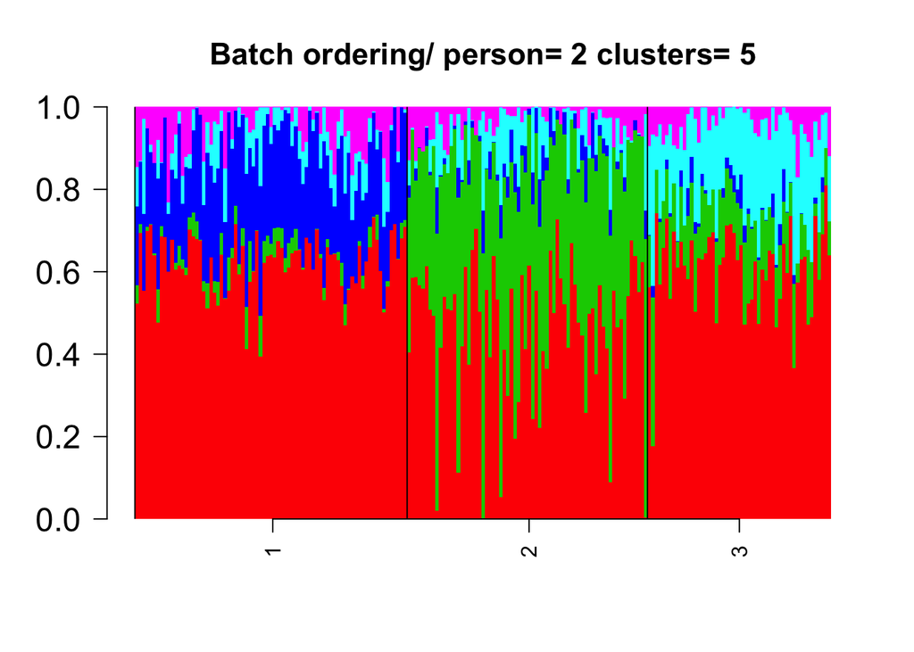

```r
structure_per_individual(molecules_single,3,nclus=5,cell_phase)
```

```
##
## Estimating on a 224 document collection.
## Fitting the 5 topic model.
## log posterior increase: 13336.523, 7179.523, 941.647, 469.072, 335.302, 252.557, 191.689, 146.925, 118.217, 99.765, 86.141, 75.101, 66.176, 59.165, 53.459, 48.886, 45.333, 42.413, 40.001, 37.984, 36.398, 35.234, 34.42, 33.81, 33.495, 32.849, 32.629, 32.383, 32.324, 32.352, done.
```

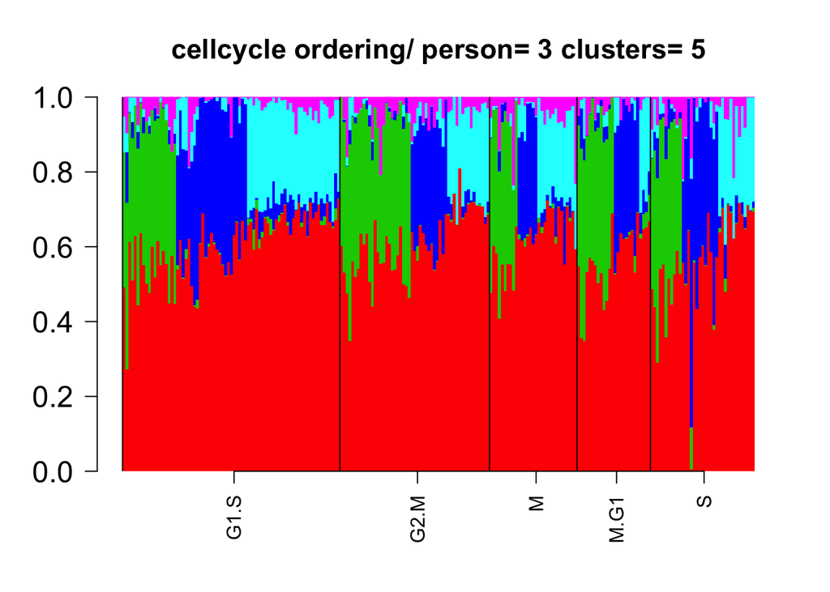

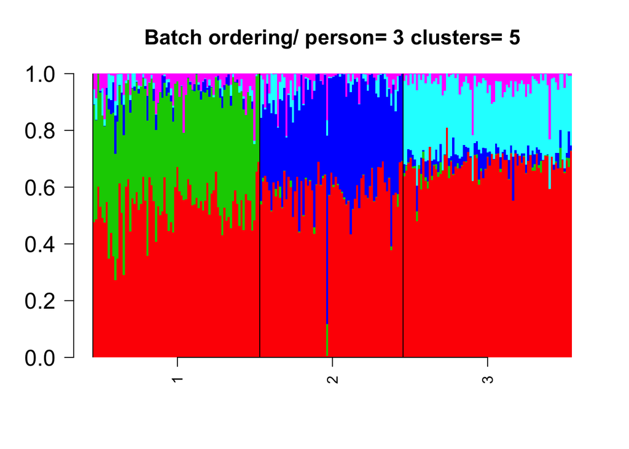

This seenms like once we constrain for the individual effect, the batch information seems to be prominently showcased in the Structure plots.

What happens when we fix one individual and one batch?…Do we then get the cell cycle specific effects ??

We consider two different senarios with fixed individual and fixed batch.

```r
  counts_data <- molecules_single
  nclus <- 5
  subgroup_id =colnames(molecules_single);
  individual_effect = unlist(lapply(strsplit(subgroup_id, "\\."), function(x) x[1]));
  batch_effect = unlist(lapply(strsplit(subgroup_id, "\\."), function(x) x[2]));
  individual_lab <- 1; batch_lab <- 1;
  indices <- which(individual_effect==unique(individual_effect)[individual_lab] &
                     batch_effect==unique(batch_effect)[batch_lab] );

  counts_ind <- counts_data[,indices];

  Topic_Clus <- topics(t(counts_ind), K=nclus, tol=0.005);
```

```
##
## Estimating on a 85 document collection.
## Fitting the 5 topic model.
## log posterior increase: 4297.873, 1005.458, 585.648, 428.016, 338.812, 274.156, 227.216, 185.407, 162.364, 144.422, 124.462, 110.5, 95.435, 81.792, 72.059, 64.781, 59.647, 56.142, 51.965, 48.223, 44.129, 39.297, 36.135, 33.575, 31.69, 29.29, 26.98, 24.54, done.
```

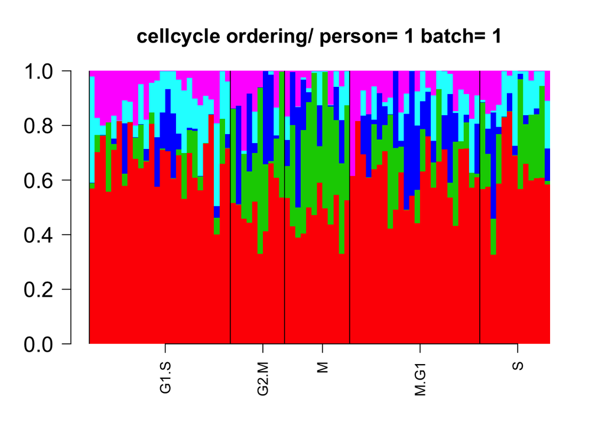

[output not shown]

[figure not shown]

```r
  cell_phase_ind <- cell_phase[indices];

  docweights_ind <- Topic_Clus$omega;

  cell_phase_ind_ordered <- cell_phase_ind[order(cell_phase_ind)];

  docweights_ind_ordered <- docweights_ind[order(cell_phase_ind),];

  barplot(t(docweights_ind_ordered),col=2:(nclus+1),axisnames=F,space=0,border=NA,main=paste("cellcycle ordering/ person=",individual_lab,"batch=",batch_lab),las=1,ylim=c(0,1),cex.axis=1.5,cex.main=1.4)

  labels = match(unique(cell_phase_ind_ordered), cell_phase_ind_ordered);
  abline(v=labels-1)

  labels_low=labels;
  labels_up=c(labels[2:length(labels)],dim(docweights_ind_ordered)[1]);
  mid_point=labels_low +0.5*(labels_up-labels_low);

  axis(1,at=mid_point, unique(cell_phase_ind_ordered),las=2);
```